# Assignment 04

Jarvis Sanders

9/15/2020

Problem #1

By graphing the data this way I am able to see that the sepal width data rises to a certain point and then decreases steadily after that with local peaks, but ultimately decreasing.

For sepal length, the data increases and decreases often. Multiple local peaks and lows.

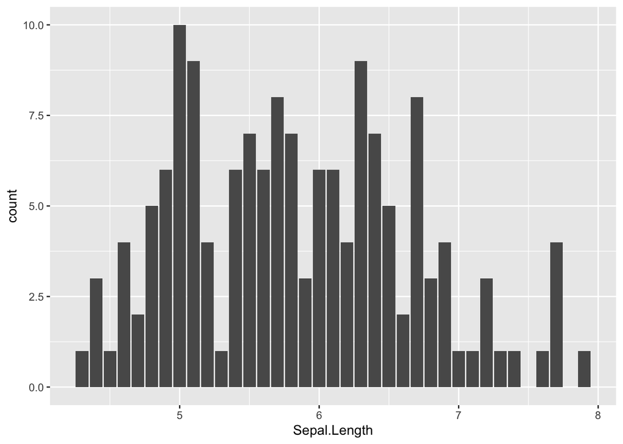

```r
library(ggplot2)
library(dplyr)
ggplot(data = iris) +
  geom_bar(mapping = aes (x = Sepal.Length))
```

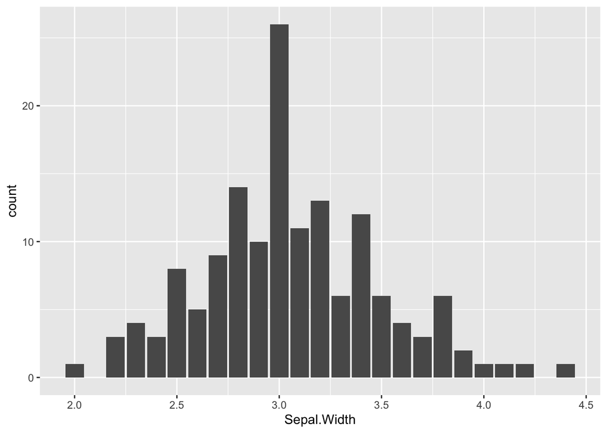

```r
ggplot(data = iris) +
  geom_bar(mapping = aes (x = Sepal.Width))
```

*Comments:*

- A bar plot is not really appropriate here; that would be useful for discrete (rather than continuous) data. You are looking for a histogram, with some work on picking a reasonable bin width. For example, see below.
- Also be sure your final graphs have appropriate labels.

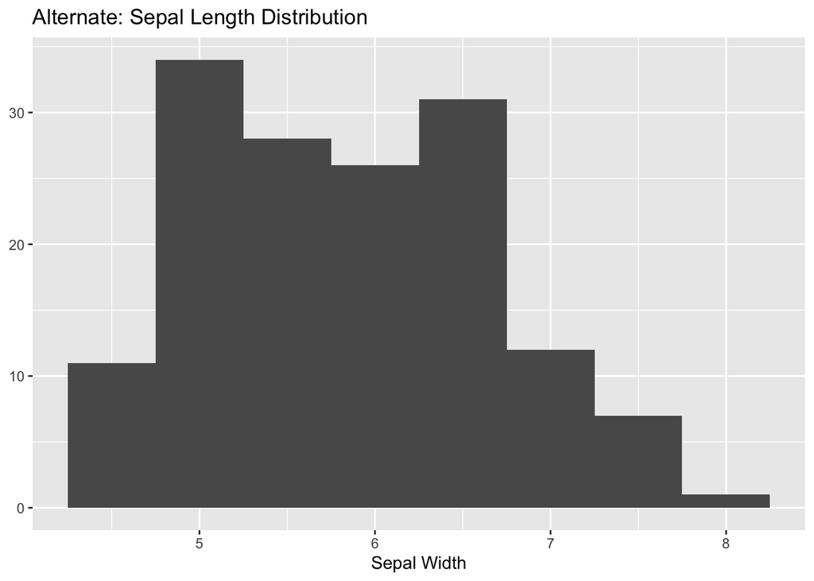

```r
ggplot(iris) +
  geom_histogram(aes(x = Sepal.Length), binwidth = 0.5) +
  labs(title = "Alternate: Sepal Length Distribution", x = "Sepal Width", y = NULL)
```

Problem #2

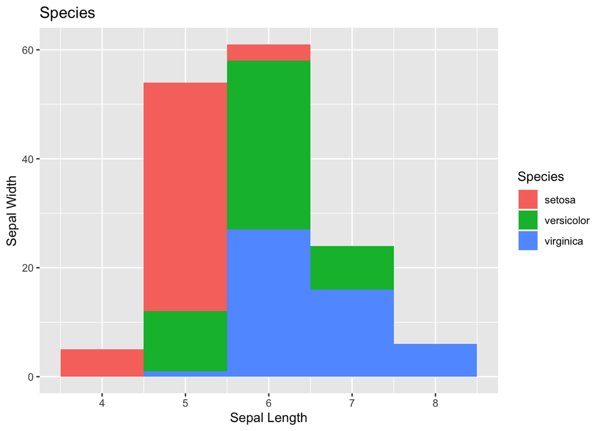

```r
ggplot(data = iris) +
  geom_histogram(aes(x = Sepal.Length, fill = Species), binwidth = 1) +
  labs(title = "Species",
       x = "Sepal Length",
       y = "Sepal Width")
```

*Comments:*

- Your binwidth is a little large here; this gives you only five categories.
- Your y-axis is not width. (You have not produced a graph for the distribution of widths here.)
- The color does help differentiate, but these are still hard to read plotted on top of each other. It will help to separate the graphs by species with a `facet_wrap`, like below:

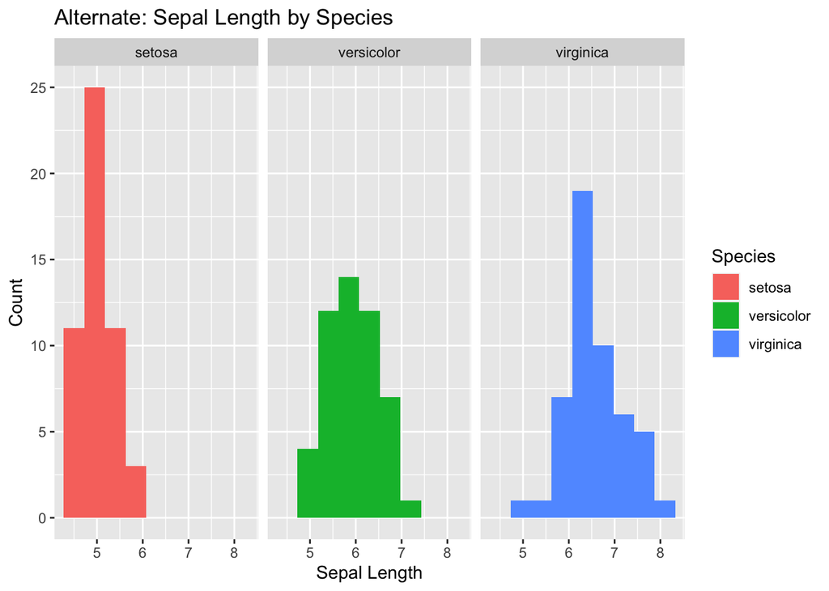

```r
ggplot(data = iris) +
  geom_histogram(aes(x = Sepal.Length, fill = Species), binwidth = .45) +
  facet_wrap( ~ Species) +
  labs(title = "Alternate: Sepal Length by Species",
       x = "Sepal Length",
       y = "Count")
```

Problem #3

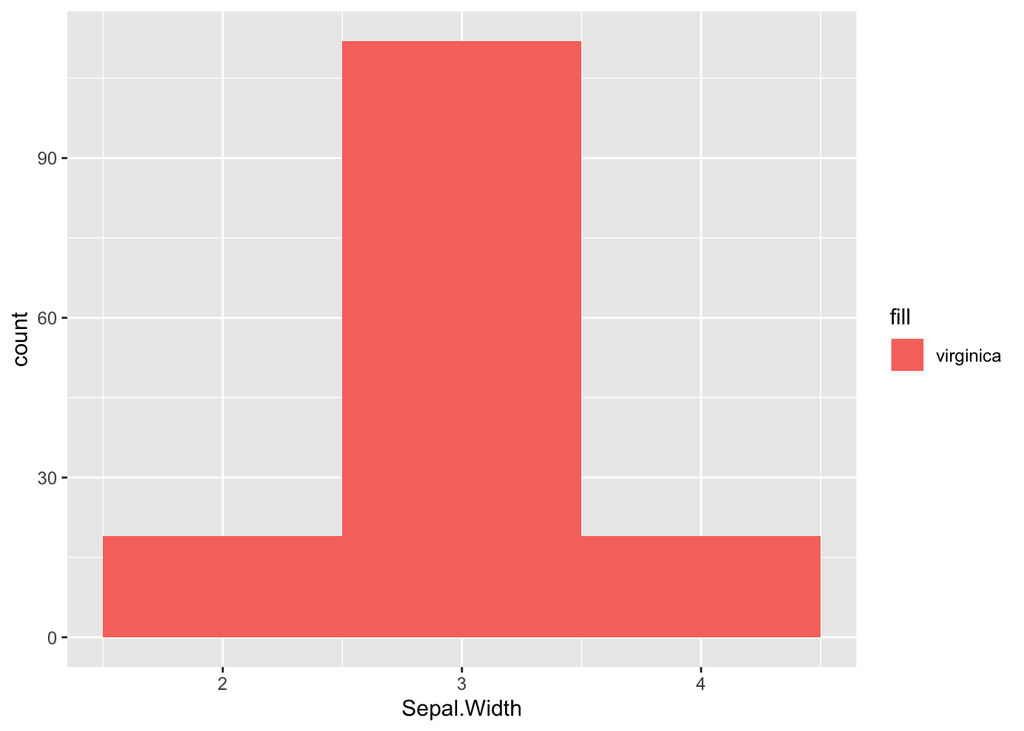

```r
ggplot(data = iris) +
  geom_histogram(mapping = aes (x = Sepal.Width, fill = "virginica"), binwidth = 1)
```

*Comments:* Again, this is too large of a binwidth. (You only have three categories!) What do you see about the distribution of this variable?